# Sequential reduction in a simple occupancy model

Author

Christopher Cahill

Published

April 10, 2026

# 1 Occupancy: a discrete latent variable

The MacKenzie et al. (2002) occupancy model has two levels:

**Ecological process** — true occupancy at site $i$:
$$z_i \sim \text{Bernoulli}(\psi), \qquad i = 1, \ldots, R$$

**Observation process** — what we record on visit $j$:
$$y_{ij} \mid z_i \sim \text{Bernoulli}(z_i \cdot p), \qquad j = 1, \ldots, T$$

| Symbol | Meaning |
| --- | --- |
| $z_i \in \{0, 1\}$ | True occupancy — latent, never observed |
| $y_{ij} \in \{0, 1\}$ | Detected (1) or not (0) at site $i$, visit $j$ |
| $\psi$ | Occupancy probability |
| $p$ | Detection probability given the species is present |

The product $z_i \cdot p$ encodes an important constraint: if a site is unoccupied ($z_i = 0$), detection probability is exactly zero regardless of $p$. This means any observed detection immediately forces $z_i = 1$ with certainty — a fact we will see reflected clearly in the clique tables later.

## 1.1 Marginal maximum likelihood

We want to estimate $\psi$ and $p$ from the observed detection histories $\mathbf{Y}$. The complication is that $z_i$ is never observed, so we cannot evaluate the likelihood by plugging in a known $z_i$. Instead we must **marginalise** over $z_i$ — that is, sum the joint probability over both possible occupancy states, weighting each by its probability under the model:

$$\mathcal{L}(\psi, p \mid \mathbf{Y}) =
\prod_{i=1}^{R}
\sum_{z_i \in \{0,1\}}
\underbrace{\text{Bernoulli}(z_i \mid \psi)}_{\text{occupancy model}}
\prod_{j=1}^{T}
\underbrace{\text{Bernoulli}(y_{ij} \mid z_i \cdot p)}_{\text{observation model}}$$

On the log scale, using the fact that sites are independent:

$$\ell(\psi, p) = \sum_{i=1}^{R}
\log \left[
\sum_{z_i \in \{0,1\}}
\text{Bernoulli}(z_i \mid \psi) \prod_{j=1}^{T} \text{Bernoulli}(y_{ij} \mid z_i \cdot p)
\right]$$

We can estimate the parameters of this problem using marginal maximum likelihood: we maximise $\ell$ over $(\psi, p)$ after integrating out the latent states. In this case, $\text{Bernoulli}(z_i \mid \psi)$ is the occupancy submodel (see MacKenzie et al. 2002).

For a binary $z_i$ the inner sum has exactly two terms and is trivial to evaluate directly. The reason to study sequential reduction here is that the identical algorithmic logic handles harder cases. The binary occupancy model gives us a simple setting where we can verify the algorithm against the exact answer step by step.

# 2 Factor graph representation

A factor graph makes the multiplicative structure of the likelihood explicit. It has two kinds of nodes:

- **Circles** — latent variables ($z_i$)
- **Squares** — factors, i.e. individual terms in the product

Edges connect each factor to the variables it depends on. For one site, the graph has a single latent node $z_i$ connected to the occupancy submodel factor $A = \text{Bernoulli}(z_i \mid \psi)$ above it, and to the $T$ observation factors $B_j = \text{Bernoulli}(y_{ij} \mid z_i \cdot p)$ below it. Each $B_j$ is in turn connected to the corresponding observed value $y_{ij}$ (shaded squares).

Two structural features of this graph matter. First, all factors at a given site share the same latent variable $z_i$, so there is only one variable to sum out per site — and as we will see, the largest intermediate table we ever need has just two entries. Second, each site has its own independent latent state $z_i$, so the marginalisation can be done one site at a time and the per-site log-likelihoods sum to give the total.

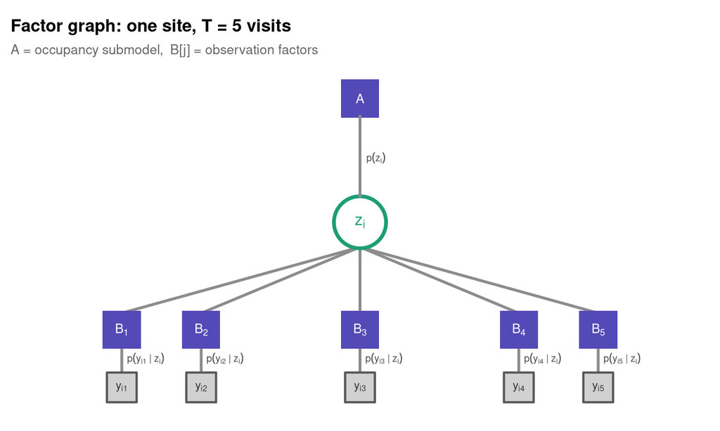

Figure 1: Factor graph for one site, T = 5 visits. Blue squares are factors; grey squares are observed y values. A = occupancy submodel Bernoulli(z[i] | psi), B[j] = observation factors Bernoulli(y[i,j] | z[i] * p). All factors connect to the single latent node z[i], so there is only one variable to sum out.

# 3 Simulating occupancy data

```r
set.seed(333)
psi <- 0.6 # true occupancy probability
p <- 0.7 # true detection probability
n_sites <- 10 # R
n_visits <- 5 # T
z_true <- rbinom(n_sites, size = 1, prob = psi)
Y <- matrix(
  rbinom(n_sites * n_visits,
    size = 1,
    prob = rep(z_true, each = n_visits) * p
  ),
  nrow = n_sites,
  ncol = n_visits,
  byrow = TRUE,
  dimnames = list(
    paste0("site_", seq_len(n_sites)),
    paste0("visit_", seq_len(n_visits))
  )
)
print(z_true)
```

```
 [1] 1 1 0 1 1 0 0 1 1 1
```

```r
print(Y)
```

```
        visit_1 visit_2 visit_3 visit_4 visit_5
site_1        1       1       0       1       0
site_2        0       1       0       1       1
site_3        0       0       0       0       0
site_4        1       1       1       1       1
site_5        1       1       1       1       0
site_6        0       0       0       0       0
site_7        0       0       0       0       0
site_8        1       1       1       1       1
site_9        1       0       1       1       1
site_10       1       0       0       1       1
```

We will trace the algorithm in full for site 1, then apply it to all sites.

```r
y_site1 <- Y[1, ]
cat("Site 1 detections:", y_site1, " | true z:", z_true[1], "\n")
```

```
Site 1 detections: 1 1 0 1 0  | true z: 1
```

Any site with at least one detection must have $z_i = 1$, since detections are impossible when $z_i = 0$.

# 4 Direct summation: the reference answer

For a binary $z$ we can compute the marginal likelihood by explicitly evaluating the joint log-probability at $z = 0$ and $z = 1$, then applying log-sum-exp to combine them. This gives the exact answer and serves as the reference we will match with sequential reduction.

```r
log_lik_direct <- function(y, psi, p) {
  log_terms <- sapply(0:1, function(z) {
    dbinom(z, size = 1, prob = psi, log = TRUE) +
      sum(dbinom(y, size = 1, prob = z * p, log = TRUE))
  })
  log_sum_exp(log_terms)
}
ref <- log_lik_direct(y_site1, psi, p)
cat("log-likelihood for site 1 [direct]:", round(ref, 6), "\n")
```

```
log-likelihood for site 1 [direct]: -3.988796
```

# 5 Sequential reduction

## 5.1 Why not the Laplace approximation?

TMB’s default approach for random effects is the Laplace approximation, which approximates the integral over a random effect by fitting a Gaussian to the integrand at its mode. This works well when the integrand is smooth and roughly bell-shaped — which is the case for many continuous random effects.

It fails for discrete random effects like $z_i$. A binary variable has no mode in the calculus sense, no smooth curvature to fit a Gaussian to, and the “integral” is really just a two-term sum.

Sequential reduction sidesteps this entirely. Rather than approximating the integral, it computes it exactly by evaluating the integrand at every point in the support of $z_i$ and summing. For a binary $z_i$ that is two evaluations.

## 5.2 The key idea: avoid building the full joint table

The naive way to compute the marginal likelihood for all $R$ sites at once would be to build a table of joint probabilities over all possible combinations of $(z_1, z_2, \ldots, z_R)$. That table has $2^R$ entries — it doubles with each additional site and becomes completely impractical even for moderate $R$.

Sequential reduction avoids this by exploiting the conditional independence structure of the model (see graphical representation above). Because each site’s factors only depend on that site’s $z_i$ — and not on $z_j$, the latent occupancy state at any other site $j \neq i$ — we never need to consider $z_i$ and $z_j$ jointly. We can sum out $z_i$ using only the factors that involve $z_i$, and the result is a scalar that we accumulate into the total log-likelihood. The largest table we ever build has exactly two entries.

This is the computational payoff: instead of one table of size $2^R$, we build $R$ tables of size $2$, one per site. Whether sequential reduction remains feasible depends entirely on the adjacency structure of the latent variables, as encoded in the adjacency matrix. In the standard MacKenzie occupancy model, sites are independent — whether a species occupies site $i$ tells us nothing about whether it occupies site $j$ — so the tables never grow beyond size 2 regardless of how many sites or visits there are and hence the method scales trivially. For the simulated model above, the adjacency matrix is diagonal, reflecting this independence:

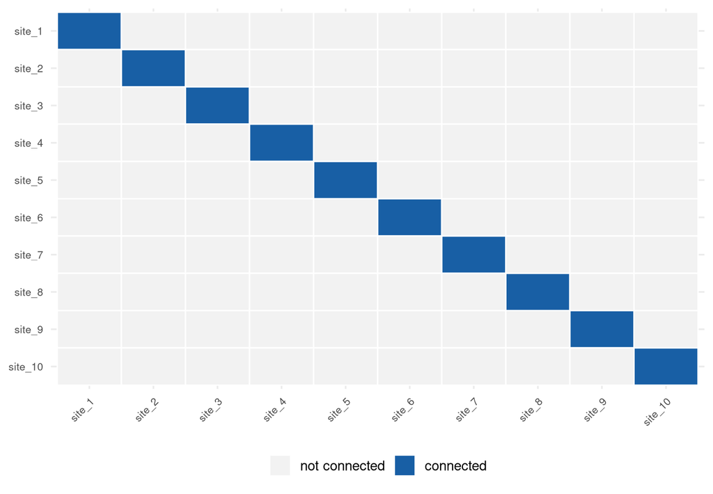

Figure 2: Adjacency matrix for the MacKenzie et al. occupancy model. Sites are independent so the matrix is diagonal with no off-diagonal connections. This is why sequential reduction never needs to build a table larger than 2 entries: summing out z_i at any site involves only that site’s own factors.

However, imagine instead that the discrete random effect of interest was spatially structured: a species that occupies one area is more likely to occupy a nearby area than a distant one. In that case, the latent states $z_i$ and $z_j$ at neighbouring sites would be connected, and summing out $z_i$ would require a table that spans its neighbours as defined by the adjacency matrix. Those neighbours must then be accounted for in subsequent steps. It is ultimately this adjacency matrix structure that determines whether sequential reduction remains computationally feasible for a particular problem.

## 5.3 Formal setup

To be precise about what the sequential reduction algorithm does, we need a little notation. For site $i$, define the set of **factors** — the individual terms that make up the likelihood contribution of that site:

$$f_0(z_i) = \log \text{Bernoulli}(z_i \mid \psi), \qquad \text{the occupancy submodel}$$
$$f_j(z_i) = \log \text{Bernoulli}(y_{ij} \mid z_i \cdot p), \quad j = 1, \ldots, T, \qquad \text{one observation factor per visit}$$

Each factor is a function of $z_i$ evaluated at fixed parameter values $(\psi, p)$ — that is, we sweep over $z_i$ while holding the parameters constant. Because $z_i \in \{0, 1\}$, each factor can be fully described by two numbers — its value at $z_i = 0$ and its value at $z_i = 1$.

A **clique** is a lookup table that stores these values. The term comes from graph theory, where a clique is a set of nodes that are all mutually connected. In our case it refers to the set of variables that must be tabulated together because they share a common factor. For a single binary variable, a clique is a 2-element named vector:

$$c = \begin{bmatrix} c(z=0) \\ c(z=1) \end{bmatrix}$$

Recalling the likelihood from above, the term inside the log for site $i$ is the joint probability of $z_i$ and all observations $y_{i1}, \ldots, y_{iT}$, summed over both values of $z_i$:

$$\ell_i(\psi, p) = \log \left[ \sum_{z_i \in \{0,1\}} \text{Bernoulli}(z_i \mid \psi) \prod_{j=1}^{T} \text{Bernoulli}(y_{ij} \mid z_i \cdot p) \right]$$

On the log scale, the product inside the sum becomes a sum of log-factors:

$$\ell_i(\psi, p) = \log \sum_{z_i \in \{0,1\}} \exp\!\left(f_0(z_i) + \sum_{j=1}^{T} f_j(z_i)\right)$$

The inner expression is just: for a fixed value of $z_i$, add up all the log-probability contributions from every factor. Do this for $z_i = 0$ and $z_i = 1$, exponentiate both, add them, and take the log. The sequential reduction algorithm does this sequentially in small steps.

## 5.4 Step 1: initialise one clique per factor

We evaluate each factor at $z_i = 0$ and $z_i = 1$ and store the two values as a named vector. This is the initialisation step: we are simply tabulating each term in the likelihood on the grid.

## 5.5 The grid

```r
grid_z <- c(0L, 1L) # the two possible values of z
```

```r
clique_A <- dbinom(grid_z, size = 1, prob = psi, log = TRUE)
names(clique_A) <- paste0("z=", grid_z)
cat("Clique A  [log Bernoulli(z | psi)]:\n")
```

```
Clique A  [log Bernoulli(z | psi)]:
```

```r
print(round(clique_A, 4))
```

```
    z=0     z=1
-0.9163 -0.5108
```

```r
clique_B <- lapply(seq_len(n_visits), function(j) {
  lv <- dbinom(y_site1[j],
    size = 1, prob = grid_z * p,
    log = TRUE
  )
  names(lv) <- paste0("z=", grid_z)
  lv
})
for (j in seq_along(clique_B)) {
  cat(sprintf(
    "\nClique B%d [log Bernoulli(y_visit%d = %d | z * p)]:\n",
    j, j, y_site1[j]
  ))
  print(round(clique_B[[j]], 4))
}
```

```
Clique B1 [log Bernoulli(y_visit1 = 1 | z * p)]:
    z=0     z=1
   -Inf -0.3567

Clique B2 [log Bernoulli(y_visit2 = 1 | z * p)]:
    z=0     z=1
   -Inf -0.3567

Clique B3 [log Bernoulli(y_visit3 = 0 | z * p)]:
   z=0    z=1
 0.000 -1.204

Clique B4 [log Bernoulli(y_visit4 = 1 | z * p)]:
    z=0     z=1
   -Inf -0.3567

Clique B5 [log Bernoulli(y_visit5 = 0 | z * p)]:
   z=0    z=1
 0.000 -1.204
```

After this step the clique list contains six 2-element vectors, all indexed by $z_i$.

## 5.6 Step 2: merge — add log-values entry-wise

All six cliques share the same variable $z_i$. We combine them into a single clique by adding their values at each grid point:

$$\tilde{c}(z_i) = f_0(z_i) + \sum_{j=1}^{T} f_j(z_i) = \log \text{Bernoulli}(z_i \mid \psi) + \sum_{j=1}^{T} \log \text{Bernoulli}(y_j \mid z_i \cdot p)$$

On the probability scale, adding logs is the same as multiplying — which is exactly what the likelihood requires. In R, this is just vector addition:

```r
log_f_z <- clique_A
for (j in seq_along(clique_B)) {
  log_f_z <- log_f_z + clique_B[[j]]
}
cat("Merged clique:\n")
```

```
Merged clique:
```

```r
print(round(log_f_z, 4))
```

```
    z=0     z=1
   -Inf -3.9888
```

After merging, the two entries hold the total log-weight for each scenario:

- `z=0`: log-probability that the site is unoccupied *and* we saw this detection history. This will be $-\infty$ if any detection occurred.
- `z=1`: log-probability that the site is occupied *and* we saw this detection history, accounting for imperfect detection.

## 5.7 Step 3: integrate out — log-sum-exp over the grid

The last step eliminates $z_i$ by computing:

$$\ell_i = \log\!\left(e^{\,\tilde{c}(z=0)} + e^{\,\tilde{c}(z=1)}\right)$$

We use the log-sum-exp trick to do this numerically without overflow or underflow: subtract the maximum value before exponentiating, then add it back. When `z=0` is $-\infty$, this reduces to just the `z=1` entry, since $\log(0 + e^x) = x$.

```r
log_lik_SR_site1 <- log_sum_exp(log_f_z)
cat("Sequential reduction: ", round(log_lik_SR_site1, 6), "\n")
```

```
Sequential reduction:  -3.988796
```

```r
cat("Direct sum: ", round(ref, 6), "\n")
```

```
Direct sum:  -3.988796
```

The results are identical. Sequential reduction and direct summation perform the same arithmetic. SR just exploits the structure of the problem in a way that generalises to harder problems.

# 6 Figures

## 6.1 The clique values at each step

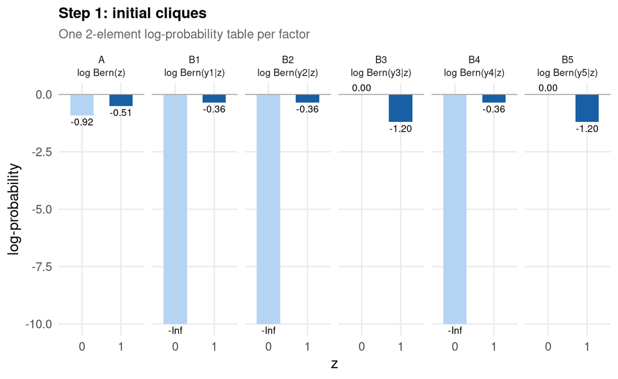

Figure 3: Step 1: one clique per factor. Each bar is the log-probability for z = 0 (light) or z = 1 (dark). Clique A is the occupancy submodel; B1-B5 are the observation factors. A -Inf bar means that value of z is ruled out by the data (a detection at an absent site is impossible).

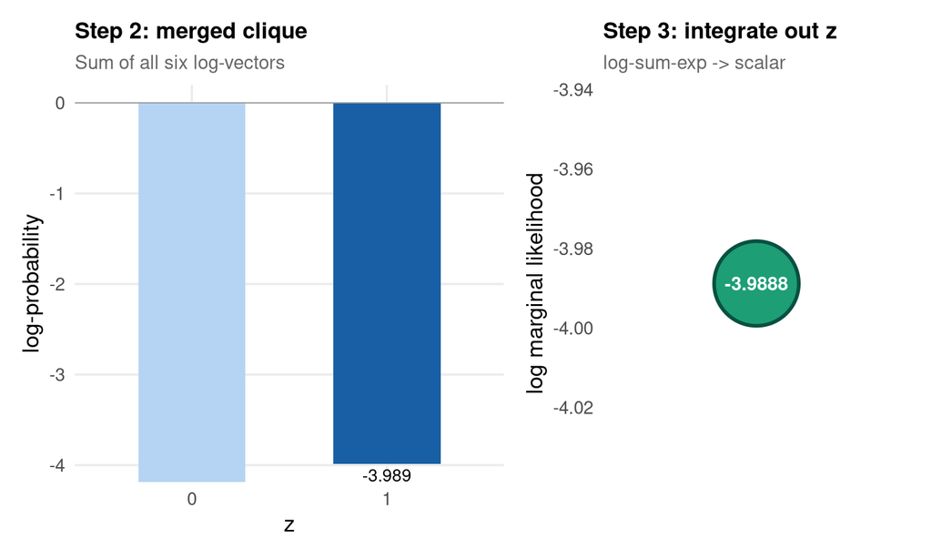

Figure 4: Steps 2 and 3. Left: the merged clique after adding all six log-vectors entry-wise. Right: log-sum-exp collapses the two-entry table to a single scalar.

## 6.2 How the clique accumulates across factors

As each factor is folded in, the gap between the two entries widens or narrows depending on what was observed. Each detection contributes the log of the detection probability to the `z=1` entry and $-\infty$ to the `z=0` entry, immediately ruling out absence. A non-detection contributes $\log(1 - p)$ to the `z=1` entry and $\log 1 = 0$ to the `z=0` entry, slightly penalising occupancy relative to absence.

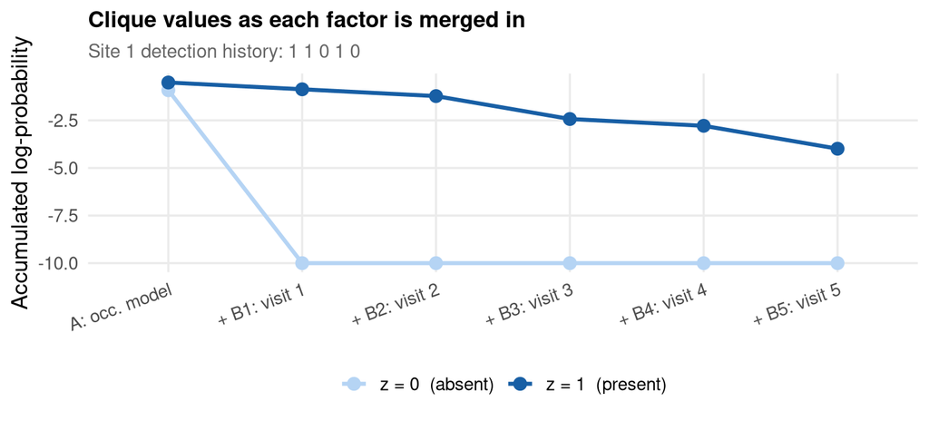

Figure 5: Cumulative clique value as each factor is folded in. The z = 1 entry pulls ahead as detections accumulate because Bernoulli(y = 1 | z = 0 * p) = 0. A detection drives the z = 0 entry to -Inf; the line is clipped at -10 for display.

# 7 All sites: the full marginal log-likelihood

Sites are independent, so we repeat the three steps for every site and sum the scalars.

```r
log_lik_SR <- function(y, psi, p) {
  grid_z <- c(0L, 1L)
  log_f <- dbinom(grid_z, size = 1, prob = psi, log = TRUE)
  for (j in seq_along(y)) {
    log_f <- log_f + dbinom(y[j], size = 1, prob = grid_z * p, log = TRUE)
  }
  log_sum_exp(log_f)
}
log_lik_total <- function(Y, psi, p) {
  sum(apply(Y, MARGIN = 1, FUN = log_lik_SR, psi = psi, p = p))
}
```

```r
sr_per_site <- apply(Y, 1, log_lik_SR, psi = psi, p = p)
direct_per_site <- apply(Y, 1, log_lik_direct, psi = psi, p = p)
cat("SR: ", round(sum(sr_per_site), 6), "\n")
```

```
SR:  -25.57574
```

```r
cat("Direct sum: ", round(sum(direct_per_site), 6), "\n")
```

```
Direct sum:  -25.57574
```

# 8 Implementing SR in RTMB

```r
library(RTMB)
dat <- list(y = Y, R = nrow(Y), T = ncol(Y))
par <- list(logit_psi = qlogis(psi), logit_p = qlogis(p), z = rep(1, dat$R))
f <- function(par) {
  getAll(par, dat)
  psi <- plogis(logit_psi)
  p <- plogis(logit_p)
  nll <- 0
  for (i in 1:R) {
    nll <- nll - dbinom(z[i], size = 1, prob = psi, log = TRUE)
    for (j in 1:T) {
      nll <- nll - dbinom(y[i, j], size = 1, prob = z[i] * p, log = TRUE)
    }
  }
  nll
}

imethod <- list(z = TMB::SR(c(0, 1), discrete = TRUE))
obj <- MakeADFun(f, par, random = c("z"), integrate = imethod)
-obj$fn()
```

```
[1] -25.57574
```

And we can see that we get the same answers as the base R implementations above. We can estimate the marginal maximum likelihood estimates via `nlminb()`:

```r
opt <- nlminb(obj$par, obj$fn, obj$gr)
```

```
outer mgc:  2.461866
outer mgc:  0.5883167
outer mgc:  0.3788888
outer mgc:  0.02169545
outer mgc:  0.0009960712
outer mgc:  7.451863e-05
outer mgc:  1.526918e-06
```

```r
opt
```

```
$par
logit_psi   logit_p
0.8494022 1.2136389

$objective
[1] 24.91831

$convergence
[1] 0

$iterations
[1] 6

$evaluations
function gradient
       8        7

$message
[1] "relative convergence (4)"
```

# 9 Connection to the TMB source code

`log_lik_SR()` is an R translation of the `sequential_reduction` struct in TMB. The full C++ implementation is in [`graph_transform.hpp`, lines 535–688](https://github.com/kaskr/adcomp/blob/3b97ab6d7186eb06a04ccc46915b8d14364379f8/TMB/inst/include/TMBad/graph_transform.hpp#L535-L688).

| This tutorial | TMB (`graph_transform.hpp`) | Role |
| --- | --- | --- |
| `grid_z <- c(0L, 1L)` | `sr_grid` | Defines the integration grid |
| `dbinom(grid_z, ...)` | `tabulate()` | Evaluates the AD tape at each grid point to fill the clique table |
| `log_f <- log_f + ...` | `merge(i)` | Adds log-values of cliques sharing variable $i$; handles multi-dim stride arithmetic in the general case |
| `log_sum_exp(log_f)` | `update(i)` | log-sum-exp over the grid of variable $i$, collapsing one table dimension |
| `apply(Y, 1, log_lik_SR, ...)` | `update_all()` | Iterates over all random variables in the prescribed order |
| `sum(sr_per_site)` | `get_result()` | Returns the total marginal log-likelihood scalar |

The one difference that matters: in TMB the clique entries are `TMBad::ad_aug` objects rather than plain doubles. This means `update(i)` records every arithmetic operation on the AD tape as it runs, so the gradient of the log-likelihood with respect to $\psi$ and $p$ is computed simultaneously with the likelihood itself.